# What (biostats) should I know for the CACE?

Jenine Harris

February 15, 2019

## The biostats questions on the CACE are from your courses

- Foundations of Biostatistics & ALM (everyone)
  - Content covers two broad biostatistics competencies
- Advanced Data Analysis (Epi/Biostat concentrators)
  - Content covers additional more specific biostatistics competencies for Epi/Biostat concentrators

[figure not shown]

## Biostatistics competencies (everyone)

- Analyze quantitative data using biostatistics, informatics, computer-based programming and software, **as appropriate**.
  - Translation: Select and compute the appropriate statistics for different situations
- Interpret results of data analysis for public health research, policy or practice.

## Competency 1

Analyze quantitative data using biostatistics, informatics, computer-based programming and software, as appropriate.

**….That is so general! What should I study?….**

[figure not shown]

Study your course materials from Foundations of Biostatistics and ALM:

- Descriptive statistics to describe a sample (e.g., means, frequencies, percents)
- Inferential statistics to infer from a sample to a population (e.g., chi-squared, t-tests, regression)

Think about the common situations in your work and in the research you read. Be able to choose and compute the appropriate statistic(s) for the situation, such as…

## Describing a sample of people or things

- Use appropriate descriptive statistics for the variable(s) you are examining:
  - mean
  - median
  - standard deviation
  - standard error
  - range or interquartile range (IQR)
  - frequencies
  - percents
  - mode (rarely used)

## Comparing a person or a group to a sample or population

- Compare a score of one observation to the rest of a sample
  - z-score
- Compare the central tendency of a group to a hypothesized or population value
  - one-sample t-test
  - sign test

## Determining whether two characteristics are statistically significantly related (e.g., smoking and depression)

- Association between two categorical variables
  - chi-squared
  - odds ratio and confidence interval
- Association between two continuous variables
  - correlation coefficient
  - Spearman’s rho

[figure not shown]

## Determining whether two characteristics are statistically significantly related (more)

- One continuous variable and one binary variable (comparing central tendency for two groups)
  - independent samples t-test
  - Mann-Whitney U test
- One continuous variable and one categorical variable with 3+ categories (compare central tendency across more than two groups)
  - ANOVA
  - Kruskal-Wallis

## Predicting or explaining a continuous or binary outcome

- Predict or explain a continuous outcome
  - Linear regression
- Predict or explain a binary outcome
  - Logistic regression

## Competency 2

Interpret results of data analysis for public health research, policy or practice.

## Report and interpret the results of each test above

- Know which statistics to report in each situation, for example:
  - Chi-squared test: Chi-squared statistic, df, p-value, percentages across groups to show differences or similarities
  - Linear regression: Model significance (F with df and p-value), Model fit (R-squared), predictor direction, magnitude, significance (b & p)
- Review how to interpret the values reported with each test
- Think about clear ways to convey the information to an audience

[figure not shown]

## Interpret tables and graphs

- Be able to find and interpret statistics in tables in reports and published papers
  - Know the difference between a row percent and a column percent!
- Be able to read typical types of graphs
  - bar graph (including grouped and stacked bar graphs)
  - scatterplot
  - histogram
  - line graph

[figure not shown]

## Create tables and graphs

- Use appropriate graphs given the data type(s) (e.g., scatterplot is for two continuous variables)
- Create tables and graphs using clear and complete formatting, for example:
  - Use labels that everyone can understand (YES: Smoking status, NO: var105b_ss)
  - Include a descriptive title (YES: Characteristics of 500 students surveyed about health behavior in 2018., NO: Descriptive statistics for the sample.)
  - Include labels on both axes
  - Limit decimal places to 2 or 3 and be consistent
- Avoid formatting that can be misleading such as starting an axis at a high number to make a difference appear bigger

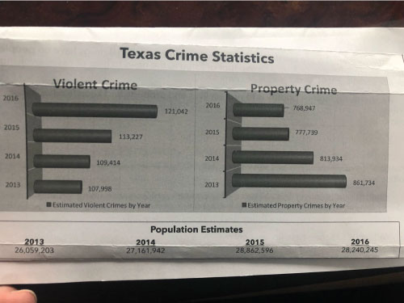

## Biostat competencies (Specializers only)

- Describe preferred methodological alternatives to commonly used statistical methods when assumptions are not met.
- Apply and interpret common statistical methods for inference (e.g., ANOVA, linear and logistic regression, survival analysis) found in public health studies.
- Describe principles and the application of key concepts from probability and inference to colleagues without extensive statistical training.

[figure not shown]

## Translation…deeper knowledge about the tests above plus those in Advanced Data Analysis (ADA), including:

- Assumption checking
  - Assumptions required for each test
  - How to check assumptions
  - What to do when any given assumption is not met
- Use and interpret appropriate follow-up tests
  - Standardized residuals
  - Post-hoc tests

[figure not shown]

## The bottom line

- Biostat concepts on the exam are the topics covered in your biostat courses
- Review your notes and assignments from Foundations of Biostatistics and ALM (and ADA for concentrators)
- Practice conducting and interpreting the statistical tests listed above and any others covered in your classes
- Practice stating your interpretations so they are clear to lay audiences
- Practice finding and interpreting statistical information in tables and graphs in reports and published research
- Review creating your own tables and graphs
- Formulas will be provided so focus on selecting, reporting, and interpreting statistics (not memorizing formulas)

## That’s it!

[figure not shown]